# Informe con quarto para practicar

Autor/a

Emilio L. Cano

# Datos

```r
library(palmerpenguins)
penguins
```

```
# A tibble: 344 × 8
   species island    bill_length_mm bill_depth_mm flipper_length_mm body_mass_g
   <fct>   <fct>              <dbl>         <dbl>             <int>       <int>
 1 Adelie  Torgersen           39.1          18.7               181        3750
 2 Adelie  Torgersen           39.5          17.4               186        3800
 3 Adelie  Torgersen           40.3          18                 195        3250
 4 Adelie  Torgersen           NA            NA                  NA          NA
 5 Adelie  Torgersen           36.7          19.3               193        3450
 6 Adelie  Torgersen           39.3          20.6               190        3650
 7 Adelie  Torgersen           38.9          17.8               181        3625
 8 Adelie  Torgersen           39.2          19.6               195        4675
 9 Adelie  Torgersen           34.1          18.1               193        3475
10 Adelie  Torgersen           42            20.2               190        4250
# ℹ 334 more rows
# ℹ 2 more variables: sex <fct>, year <int>
```

```r
KK
```

```
Error in eval(expr, envir, enclos): object 'KK' not found
```

```r
pingu <- penguins
```

## Tablas de datos con `knitr::kable()`

```r
library(dplyr)
library(knitr)
pingu |>
  slice_head(n = 10) |>
  kable()
```

| species | island | bill_length_mm | bill_depth_mm | flipper_length_mm | body_mass_g | sex | year |
| --- | --- | --- | --- | --- | --- | --- | --- |
| Adelie | Torgersen | 39.1 | 18.7 | 181 | 3750 | male | 2007 |
| Adelie | Torgersen | 39.5 | 17.4 | 186 | 3800 | female | 2007 |
| Adelie | Torgersen | 40.3 | 18.0 | 195 | 3250 | female | 2007 |
| Adelie | Torgersen | NA | NA | NA | NA | NA | 2007 |
| Adelie | Torgersen | 36.7 | 19.3 | 193 | 3450 | female | 2007 |
| Adelie | Torgersen | 39.3 | 20.6 | 190 | 3650 | male | 2007 |
| Adelie | Torgersen | 38.9 | 17.8 | 181 | 3625 | female | 2007 |
| Adelie | Torgersen | 39.2 | 19.6 | 195 | 4675 | male | 2007 |
| Adelie | Torgersen | 34.1 | 18.1 | 193 | 3475 | NA | 2007 |
| Adelie | Torgersen | 42.0 | 20.2 | 190 | 4250 | NA | 2007 |

**Practica**

Prueba a cambiar opciones con los argumentos de la función. Mira la ayuda de la función poniendo en la consola `?knitr`.

Por ejemplo, podemos cambiar el número de decimales o personalizar los encabezados:

```r
pingu |>
  slice_head(n = 10) |>
  kable(digits = 0,
        col.names = c("Especie", "Isla", "Longitud pico", "Profundidad pico",
                      "Longitud aleta", "Masa", "Sexo", "Año"))
```

| Especie | Isla | Longitud pico | Profundidad pico | Longitud aleta | Masa | Sexo | Año |
| --- | --- | --- | --- | --- | --- | --- | --- |
| Adelie | Torgersen | 39 | 19 | 181 | 3750 | male | 2007 |
| Adelie | Torgersen | 40 | 17 | 186 | 3800 | female | 2007 |
| Adelie | Torgersen | 40 | 18 | 195 | 3250 | female | 2007 |
| Adelie | Torgersen | NA | NA | NA | NA | NA | 2007 |
| Adelie | Torgersen | 37 | 19 | 193 | 3450 | female | 2007 |
| Adelie | Torgersen | 39 | 21 | 190 | 3650 | male | 2007 |
| Adelie | Torgersen | 39 | 18 | 181 | 3625 | female | 2007 |
| Adelie | Torgersen | 39 | 20 | 195 | 4675 | male | 2007 |
| Adelie | Torgersen | 34 | 18 | 193 | 3475 | NA | 2007 |
| Adelie | Torgersen | 42 | 20 | 190 | 4250 | NA | 2007 |

## Resúmenes de datos con {summarytools}

```r
library(summarytools)
pingu |>
  descr(bill_length_mm)
```

Descriptive Statistics  
pingu$bill_length_mm  
N: 344

|  | bill_length_mm |
| --- | --- |
| Mean | 43.92 |
| Std.Dev | 5.46 |
| Min | 32.10 |
| Q1 | 39.20 |
| Median | 44.45 |
| Q3 | 48.50 |
| Max | 59.60 |
| MAD | 7.04 |
| IQR | 9.27 |
| CV | 0.12 |
| Skewness | 0.05 |
| SE.Skewness | 0.13 |
| Kurtosis | -0.89 |
| N.Valid | 342.00 |
| Pct.Valid | 99.42 |

```r
pingu |>
  dfSummary()
```

Data Frame Summary  
pingu  
Dimensions: 344 x 8  
Duplicates: 0

| No | Variable | Stats / Values | Freqs (% of Valid) | Graph | Valid | Missing |
| --- | --- | --- | --- | --- | --- | --- |
| 1 | species [factor] | 1. Adelie 2. Chinstrap 3. Gentoo | 152 (44.2%) 68 (19.8%) 124 (36.0%) | IIIIIIII III IIIIIII | 344 (100.0%) | 0 (0.0%) |
| 2 | island [factor] | 1. Biscoe 2. Dream 3. Torgersen | 168 (48.8%) 124 (36.0%) 52 (15.1%) | IIIIIIIII IIIIIII III | 344 (100.0%) | 0 (0.0%) |
| 3 | bill_length_mm [numeric] | Mean (sd) : 43.9 (5.5) min < med < max: 32.1 < 44.5 < 59.6 IQR (CV) : 9.3 (0.1) | 164 distinct values | . . : . : : : : : : : : : : : : : : : : : . : : : : : : : : . | 342 (99.4%) | 2 (0.6%) |
| 4 | bill_depth_mm [numeric] | Mean (sd) : 17.2 (2) min < med < max: 13.1 < 17.3 < 21.5 IQR (CV) : 3.1 (0.1) | 80 distinct values | : : : : . : : : . . : : : : : : : : : : : : : . . | 342 (99.4%) | 2 (0.6%) |
| 5 | flipper_length_mm [integer] | Mean (sd) : 200.9 (14.1) min < med < max: 172 < 197 < 231 IQR (CV) : 23 (0.1) | 55 distinct values | : . : : : : . . . : : : : : : : : : : : : : : : | 342 (99.4%) | 2 (0.6%) |
| 6 | body_mass_g [integer] | Mean (sd) : 4201.8 (802) min < med < max: 2700 < 4050 < 6300 IQR (CV) : 1200 (0.2) | 94 distinct values | : . : : : : : : : : : : . . : : : : : : | 342 (99.4%) | 2 (0.6%) |
| 7 | sex [factor] | 1. female 2. male | 165 (49.5%) 168 (50.5%) | IIIIIIIII IIIIIIIIII | 333 (96.8%) | 11 (3.2%) |
| 8 | year [integer] | Mean (sd) : 2008 (0.8) min < med < max: 2007 < 2008 < 2009 IQR (CV) : 2 (0) | 2007 : 110 (32.0%) 2008 : 114 (33.1%) 2009 : 120 (34.9%) | IIIIII IIIIII IIIIII | 344 (100.0%) | 0 (0.0%) |

## Tabla de frecuencias

Podemos crear todas las combinaciones de tablas con las funciones de R base, y formatearlas por ejemplo con {kableExtra}:

```r
library(kableExtra)
pingu |>
  select(species, sex) |>
  table() |>
  prop.table() |>
  addmargins() |>
  kable()
```

|  | female | male | Sum |
| --- | --- | --- | --- |
| Adelie | 0.2192192 | 0.2192192 | 0.4384384 |
| Chinstrap | 0.1021021 | 0.1021021 | 0.2042042 |
| Gentoo | 0.1741742 | 0.1831832 | 0.3573574 |
| Sum | 0.4954955 | 0.5045045 | 1.0000000 |

Pero el paquete {summarytools} tiene la función `ctable()` que quizás os guste más:

```r
ctable(pingu$species, pingu$sex)
```

Cross-Tabulation, Row Proportions  
species * sex  
Data Frame: pingu

|  | sex | female | male |  | Total |
| --- | --- | --- | --- | --- | --- |
| species |  |  |  |  |  |
| Adelie |  | 73 (48.0%) | 73 (48.0%) | 6 (3.9%) | 152 (100.0%) |
| Chinstrap |  | 34 (50.0%) | 34 (50.0%) | 0 (0.0%) | 68 (100.0%) |
| Gentoo |  | 58 (46.8%) | 61 (49.2%) | 5 (4.0%) | 124 (100.0%) |
| Total |  | 165 (48.0%) | 168 (48.8%) | 11 (3.2%) | 344 (100.0%) |

**Practica**

Explora las opciones de la función (por ejemplo, para calcular las frecuencias condicionadas por columna en vez de por fila).

Por ejemplo para tener frecuencias conjuntas relativas en los porcentajes:

```r
ctable(pingu$species, pingu$sex, prop = "t")
```

Cross-Tabulation, Total Proportions  
species * sex  
Data Frame: pingu

|  | sex | female | male |  | Total |
| --- | --- | --- | --- | --- | --- |
| species |  |  |  |  |  |
| Adelie |  | 73 (21.2%) | 73 (21.2%) | 6 (1.7%) | 152 ( 44.2%) |
| Chinstrap |  | 34 ( 9.9%) | 34 ( 9.9%) | 0 (0.0%) | 68 ( 19.8%) |
| Gentoo |  | 58 (16.9%) | 61 (17.7%) | 5 (1.5%) | 124 ( 36.0%) |
| Total |  | 165 (48.0%) | 168 (48.8%) | 11 (3.2%) | 344 (100.0%) |

## Tabla 1 con {gtsummary}

```r
library(gtsummary)
pingu |>
  select(body_mass_g, species, bill_length_mm, sex) |>
  tbl_summary(by = sex)
```

| **Characteristic** | **female** N = 165<sup>1</sup> | **male** N = 168<sup>1</sup> |
| --- | --- | --- |
| body_mass_g | 3,650 (3,350, 4,550) | 4,300 (3,900, 5,325) |
| species |  |  |
| Adelie | 73 (44%) | 73 (43%) |
| Chinstrap | 34 (21%) | 34 (20%) |
| Gentoo | 58 (35%) | 61 (36%) |
| bill_length_mm | 42.8 (37.6, 46.2) | 46.8 (41.0, 50.4) |

<sup>1</sup> Median (Q1, Q3); n (%)

## Resúmenes de modelos

Varios de los paquetes mencionados nos permiten extraer la información de los modelos. La siguiente expresión crea un modelo de regresión lineal:

```r
m <- pingu |>
  lm(body_mass_g ~bill_length_mm + bill_depth_mm + sex, data = _ )
```

Con estas expresiones primero guardamos los coeficientes en una tabla, y después formateamos la tabla con {flextable}.

```r
library(flextable)
library(broom)
m |>
  tidy() |>
  flextable()
```

| term | estimate | std.error | statistic | p.value |
| --- | --- | --- | --- | --- |
| (Intercept) | 6,551.43868 | 394.407804 | 16.610824 | 0.000000000000000000000000000000000000000000002001677077 |
| bill_length_mm | 36.51909 | 5.299908 | 6.890513 | 0.000000000028399315285228353129431846507544539084944013 |
| bill_depth_mm | -257.31457 | 14.892245 | -17.278427 | 0.000000000000000000000000000000000000000000000004668175 |
| sexmale | 923.30524 | 60.723442 | 15.205087 | 0.000000000000000000000000000000000000000646111991760402 |

**Practica**

Mira la ayuda y formatea las columnas.

```r
m |>
  tidy() |>
  flextable() |>
  flextable::set_header_labels(term = "Término",
                               estimate = "Coeficiente",
                               std.error = "Error estándar",
                               statistic = "t",
                               p.value = "p-valor") |>
  colformat_double(j = 5, digits = 4)  |>
  colformat_double(j = 2:4, digits = 2)
```

| Término | Coeficiente | Error estándar | t | p-valor |
| --- | --- | --- | --- | --- |
| (Intercept) | 6,551.44 | 394.41 | 16.61 | 0.0000 |
| bill_length_mm | 36.52 | 5.30 | 6.89 | 0.0000 |
| bill_depth_mm | -257.31 | 14.89 | -17.28 | 0.0000 |
| sexmale | 923.31 | 60.72 | 15.21 | 0.0000 |

Con el paquete modelsummary sería así:

```r
library(modelsummary)
modelsummary(m)
```

|  | (1) |
| --- | --- |
| (Intercept) | 6551.439 |
|  | (394.408) |
| bill_length_mm | 36.519 |
|  | (5.300) |
| bill_depth_mm | -257.315 |
|  | (14.892) |
| sexmale | 923.305 |
|  | (60.723) |
| Num.Obs. | 333 |
| R2 | 0.687 |
| R2 Adj. | 0.684 |
| AIC | 5023.2 |
| BIC | 5042.3 |
| Log.Lik. | -2506.617 |
| F | 240.980 |
| RMSE | 449.64 |

Se pueden comparar varios modelos. Ver más ejemplos: https://vincentarelbundock.github.io/modelsummary/articles/modelsummary.html

También el paquete {gtsummary} produce tablas de modelos (puede requerir que instales un paquete adicional):

```r
tbl_regression(m)
```

| **Characteristic** | **Beta** | **95% CI**<sup>1</sup> | **p-value** |
| --- | --- | --- | --- |
| bill_length_mm | 37 | 26, 47 | <0.001 |
| bill_depth_mm | -257 | -287, -228 | <0.001 |
| sex |  |  |  |
| female | — | — |  |
| male | 923 | 804, 1,043 | <0.001 |

<sup>1</sup> CI = Confidence Interval

## Informes e interpretación

Hay un conjunto de paquetes llamado {easystats} que producen tanto tablas como resúmenes textuales con la interpretación de los análisis estadísticos. El paquete {effectsize} calcula y visualiza los efectos de un modelo, tanto en forma de tabla como gráfica.

```r
library(effectsize)
cohens_d(body_mass_g ~ sex, data = pingu)
```

```
Cohen's d |         95% CI
--------------------------
-0.94     | [-1.16, -0.71]

- Estimated using pooled SD.
```

```r
interpret_cohens_d(-0.94)
```

```
[1] "large"
(Rules: cohen1988)
```

```r
maov <- aov(body_mass_g ~ species, data = pingu)
eta_squared(maov)
```

```
# Effect Size for ANOVA

Parameter | Eta2 |       95% CI
-------------------------------
species   | 0.67 | [0.63, 1.00]

- One-sided CIs: upper bound fixed at [1.00].
```

```r
interpret_eta_squared(0.67)
```

```
[1] "large"
(Rules: field2013)
```

El paquete {report} devuelve párrafos completos, combinando toda la información

```r
library(report)
report(maov)
```

```
The ANOVA (formula: body_mass_g ~ species) suggests that:

  - The main effect of species is statistically significant and large (F(2, 339)
= 343.63, p < .001; Eta2 = 0.67, 95% CI [0.63, 1.00])

Effect sizes were labelled following Field's (2013) recommendations.
```

Para que salga el texto formateado en el formato de salida, hay que añadir la opción `results: 'asis'` en el encabezado del chunk:

```r
library(report)
report(maov)
```

The ANOVA (formula: body_mass_g ~ species) suggests that:

- The main effect of species is statistically significant and large (F(2, 339) = 343.63, p < .001; Eta2 = 0.67, 95% CI [0.63, 1.00])

Effect sizes were labelled following Field’s (2013) recommendations.

## Tablas interactivas

```r
library(reactable)
pingu |>
  reactable(filterable = TRUE,
            striped = TRUE)
```

| species | island | bill_length_mm | bill_depth_mm | flipper_length_mm | body_mass_g | sex | year |
| --- | --- | --- | --- | --- | --- | --- | --- |
| Adelie | Torgersen | 39.1 | 18.7 | 181 | 3750 | male | 2007 |
| Adelie | Torgersen | 39.5 | 17.4 | 186 | 3800 | female | 2007 |
| Adelie | Torgersen | 40.3 | 18 | 195 | 3250 | female | 2007 |
| Adelie | Torgersen | NA | NA | NA | NA | NA | 2007 |
| Adelie | Torgersen | 36.7 | 19.3 | 193 | 3450 | female | 2007 |
| Adelie | Torgersen | 39.3 | 20.6 | 190 | 3650 | male | 2007 |
| Adelie | Torgersen | 38.9 | 17.8 | 181 | 3625 | female | 2007 |
| Adelie | Torgersen | 39.2 | 19.6 | 195 | 4675 | male | 2007 |
| Adelie | Torgersen | 34.1 | 18.1 | 193 | 3475 | NA | 2007 |
| Adelie | Torgersen | 42 | 20.2 | 190 | 4250 | NA | 2007 |

[output cut: 334 more lines]

# Gráficos listos para publicar

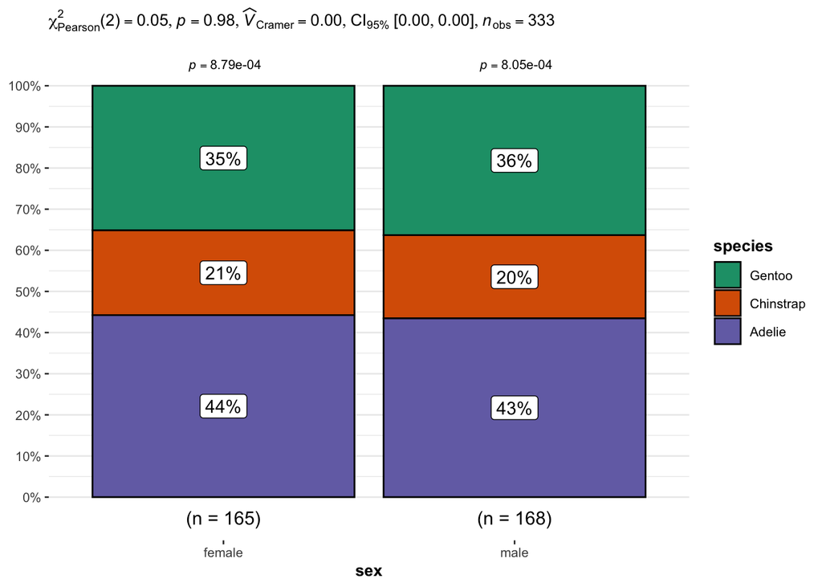

```r
library(ggstatsplot)
pingu |> ggbarstats(x = species, y = sex)
```

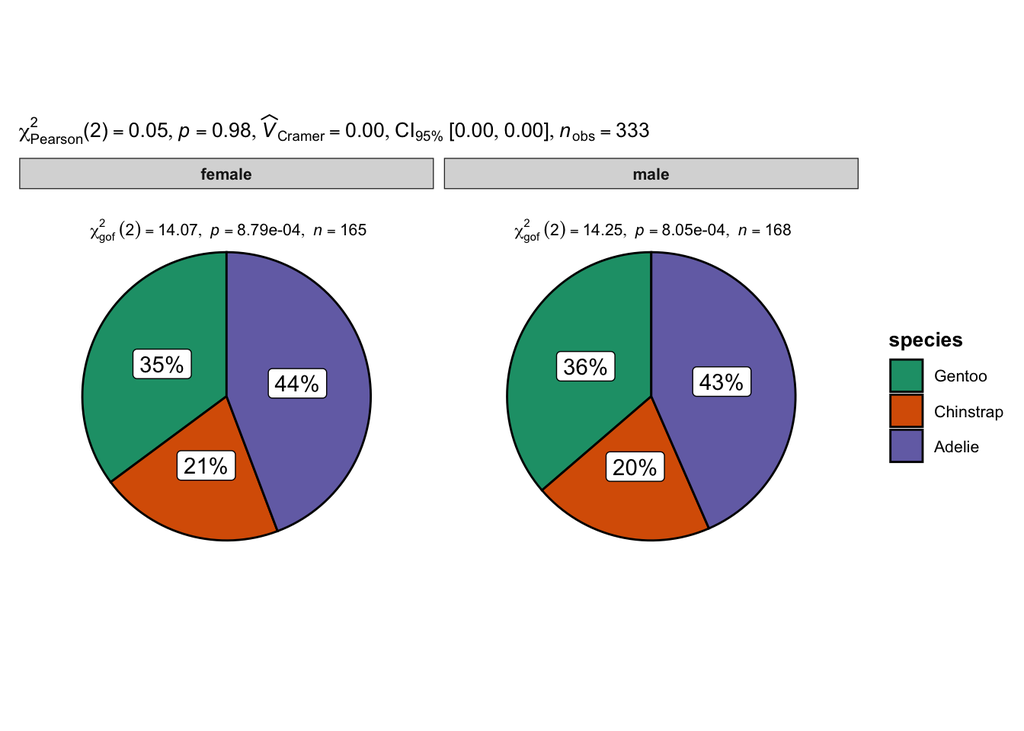

```r
pingu |> ggpiestats(x = species, y = sex)
```

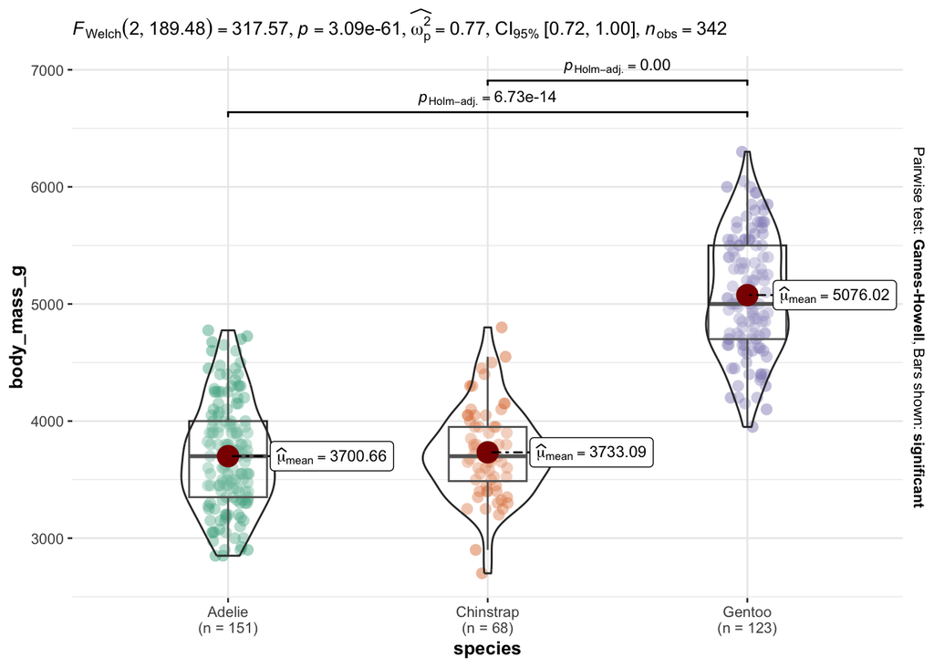

```r
pingu |> ggbetweenstats(species, body_mass_g, bf.message = FALSE)
```

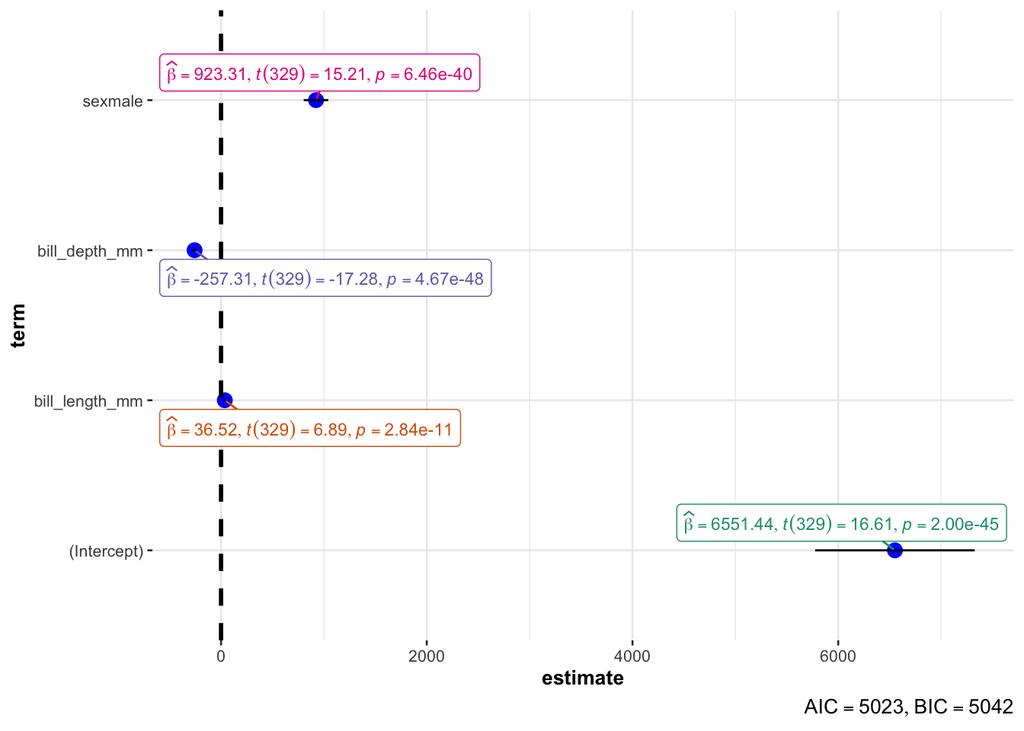

```r
m |> ggcoefstats()
```

## Practica

Explora el resto de funciones del paquete.

Por ejemplo, para analizar solo una variable, podemos obtener un histograma “enriquecido”:

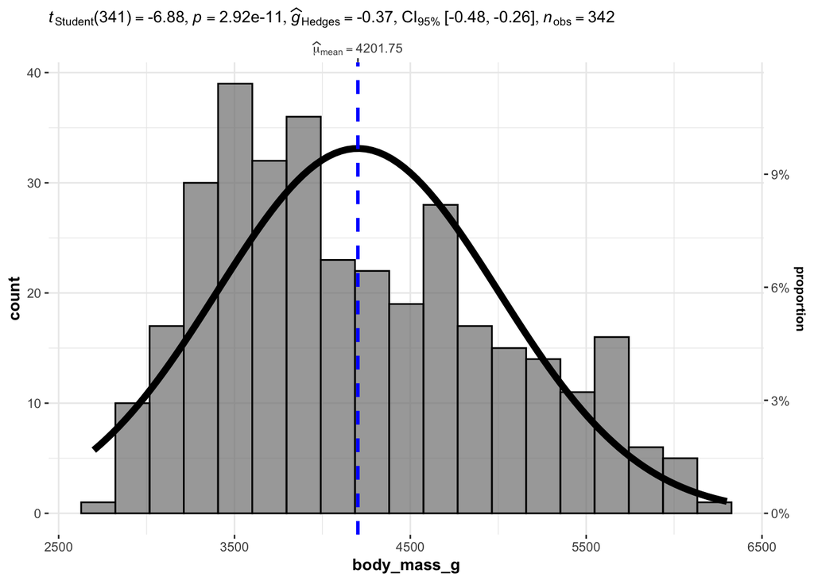

```r
pingu |>
  ggstatsplot::gghistostats(body_mass_g,
                            test.value = 4500,
                            normal.curve = TRUE,
                            bf.message = FALSE)
```